# 小朋友玩大蟒蛇 2.1

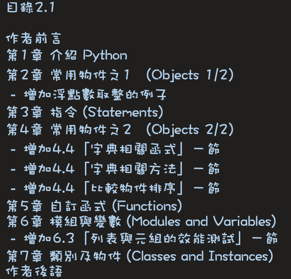

高嘉祥

2022.10.10

### 作者前言

對於從沒寫書經驗，但受困於新冠疫情緣故，閒來在家沒事就思考到2022年有沒有可以動手做的計劃。於是乎寫書的念頭就成了選項之一。

出身軟體工程師，玩程式一直是我的愛好之一。自己也正在 YouTube 學 Python 的緣故，不如邊學時做的筆記，邊把它翻譯成繁體中文，以便嘉惠後進，尤其是偏鄉小學生們乃成為我寫這本書主要目標。

又考量到沒有實際操作電腦環境，所以用很多程式片段當例子來作參考。雖然有筆上談兵之嫌，然一旦有實作演練的環境下，這本書也可當入門工具書的參考。

本書共分7章。

開頭第1章 Python 簡介對剛入門的小朋友可以從此章入手。依循 Dennis Ritchie 介紹 C 語言的傅統，從 'Hello World' 開始。

第2章進入常用的基本資料介紹，像如何定義、訪問及運算等。另外第4章也是常用的基本資料介紹，但較複雜所以另闢一章討論。

中間插入第3章的是介紹常用的程式指令，讓小朋友可以動手寫一些小程式。

接着第5章讓小朋友開始思考把有用的方法或邏輯變成可重複使用的函式。

第6章進入模塊化觀念及善用變數，打好架構軟體工程的基礎。

最後第7章介紹物件導向的核心，如何應用類別模型解決問題。

這本書先以電子書免費流通，歡迎拷貝。當然書中若有瑕疵在所難免，隨時電郵指教。小朋友有任何疑問，也可以來電郵討論。若是會使用 Anaconda Jupyter 者，可到我的 GitHub 下截 [Notebook](https://github.com/mkaoy2k/Kids-Lets-Play-Python)。

高嘉祥 2022.1.31

## 第1章 介紹 Python

Python 是人類用來與電腦溝通的程式語言之一。就像早期的人學程式語言就要學 C程式語言與電腦溝通一樣，現在人們又多了一個學習選擇是 Python。

就像人類語言為便於溝通會一再演化一樣，Python 也從前一代語言程式演化成較易懂又好學的。所以 Python 成為時下最夯的程式語言之一。

原來 Python 英文是「蟒蛇」的意思。發明者 Guido van Rossum (1956-) 當初在一邊設計這套程式語言系統的時候，也正在看一部 1970 年代有關蟒蛇的連續劇，於是乎突發其想就命名它為 「Python」。

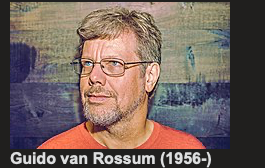

好了，現在開始學習。讓我們試著寫第一個 Python 程式看看吧！

#### 問：如何請 Python 列印：哈囉， 您好！

答：很簡單。

Python 只要用一行指令就可以了，這個指令叫列印指令如下：

```python
print('哈囉，您好!')
```

```
哈囉，您好!
```

### 介紹「列印 」指令 (print statement)

#### 語法

```
print (參數列)
```

Python 設計列印指令就是讓我們告訴它印出括號裡頭的東西，Python 稱它為參數列 (就是一串我們想印出來的訊息)。

如同上面例子，印出來的是一串打招呼的訊息：**哈囉，您好！**

太好了！用一個指令，第一個哈囉程式就完成了。 是不是很簡單呢？

#### 問：列印指令括號𥚃，前後都有個單引號，怪怪的，是啥東西啊？

答： 單引號是告訴 Python 參數列只有一個東西。

Python 好像是一部遊戲，有很多寶物一樣。資料對 Python 就是寶物了。而且每一個寶物都由不同包裝盒裝著。這些引號就是一個寶物盒之一，包裝字串訊息的。

Python 用這些引號來包裝我們要的訊息。讓我們進一步打開 Python 的藏寶箱，來看一下 Python 常用的幾種寶物盒子吧。

Python 把它的寶物盒取了一個專有名詞叫「物件 (Object)」，有點文謅謅的，英文翻譯過來的，沒辦法啦！而要學好 Python 就必須記住一些專有名詞及其代表的意義。

現在我們學習先了解下面五類常用的物件吧。

我們將會陸續介绍给大家，依序如下：

1. 字串 (String)
2. 數字 (Number)
3. 布林值（Boolean）
4. 列表 (List), 元組 (Tuple), 集合 (Set)
5. 字典 (Dictionary)

前面三類（1-3）屬於初级的基本資料類型， 在第2章我們就要學習的。而後面两類（4-5）物件就觀念比較複雜一點，屬於進階的資料類型，我們在後面另外第4章才繼續來學習。